# Solutions, week 2

## Loading packages

As always, the first thing I have to do is load the **tidyverse** package. Remember, as I have already installed the tidyverse package on this computer, I do not need to run **install.packages(“tidyverse”)**. I can go straight to the command below:

```r
library(tidyverse)
```

## Loading data

Let’s load the data from the web!

```r
amy <- read_csv("https://bit.ly/amy-w")
taylor <- read_csv("https://bit.ly/swifty-data")
fleet <- read_csv("https://bit.ly/fleetwood-mac-data")
```

## Task

- Question 1 - How many of each of Amy Winehouse’s songs are in each key? (C sharp, E, etc)

The first thing I would do is look at the data, to find a variable that describes the key. I can do this using some of the code from last week. For example, I can look at the names of each variable:

```r
names(amy)
```

I can get a summary of the dataset.

```r
summary(amy)
```

I can look at the dataset in a window.

```r
View(amy)
```

And here’s a bit of code I use all the time! Don’t worry about understanding the mechanics of this code chunk. All you need to know is that it gives you the name of each variable and what type of variable it is (e.g. numeric, categorical, character etc.). You need to have tidyverse loaded to use it.

```r
amy %>%
  map_chr(class)
```

From this exploration of the data, I’ve found the right variable: key. I know this is the right one because it has a name which seems correct, and I’ve looked at the data and seen the observations contain letters that indicate keys (e.g. C#, D etc.). I could also read more about the variables at this link if I wanted to be sure.

So let’s make the graph.

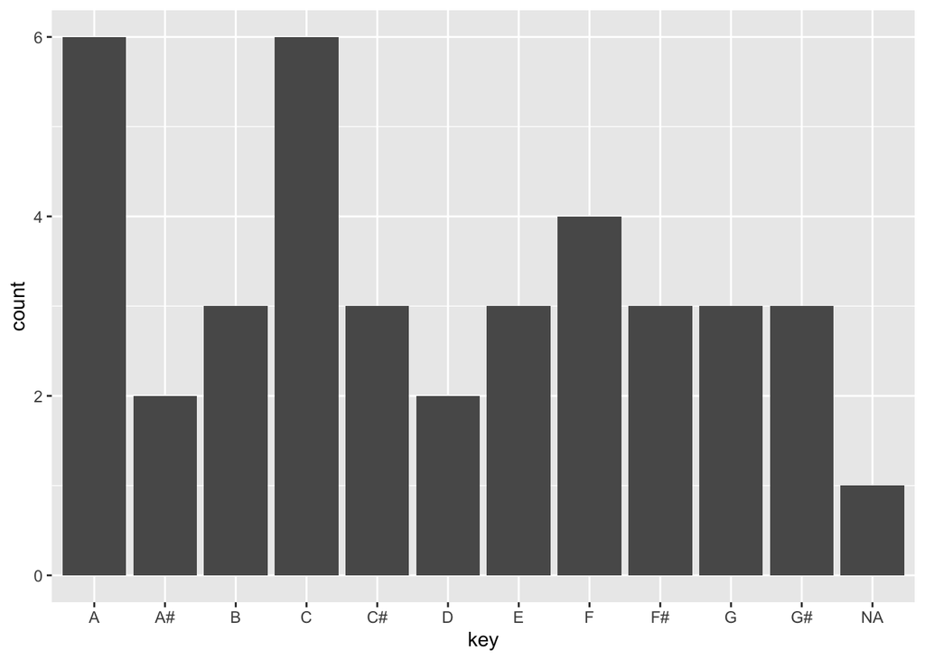

```r
ggplot(data = amy) +
  aes(x = key) +
  geom_bar()
```

- Question 2 - on which Taylor Swift albums are there the biggest number of tracks that are labelled as “explicit”?

The relevant variable in this question is explicit. But I also have to include album somewhere in my graph, as the question is asking for me to break it down by album. Note that the album variable is just called album in this dataset, not album_name!

There’s a few ways to do this. First I’ll show the most popular way in your submissions. And I think this is a great solution. So if you got it, well done!

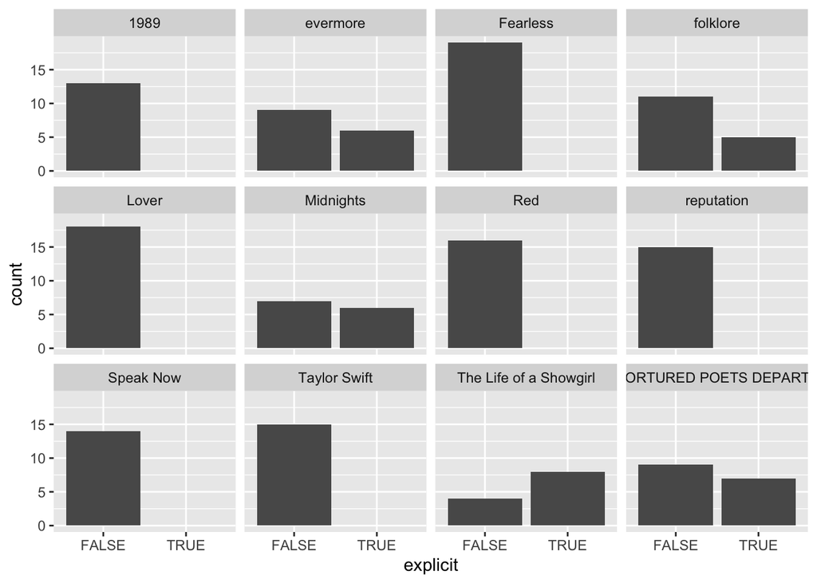

```r
ggplot(data = taylor) +
  aes(x = explicit) +
  geom_bar() +
  facet_wrap(~album)
```

Below is another solution some people used. They used a technique we did last week, **geom_bar(position = “dodge”)**. The album names aren’t readable, but we’ll get to that in another session.

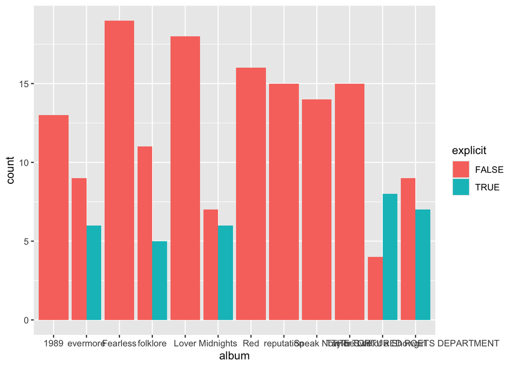

```r
ggplot(data = taylor) +
  aes(x = album, fill = explicit) +
  geom_bar(position = "dodge")
```

- Question 3 - Which Amy Winehouse album has the lowest valence?

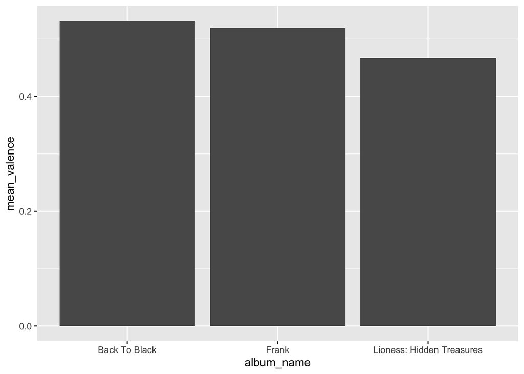

```r
amy %>%
  group_by(album_name) %>%
  summarise(mean_valence = mean(valence, na.rm = TRUE)) %>%
  ggplot() +
  aes(x = album_name, y = mean_valence) +
  geom_col()
```

### Task - do the same for another artist

- Question 4 - How many of each of Fleetwood Mac’s songs are in each key? (C sharp, E, etc)

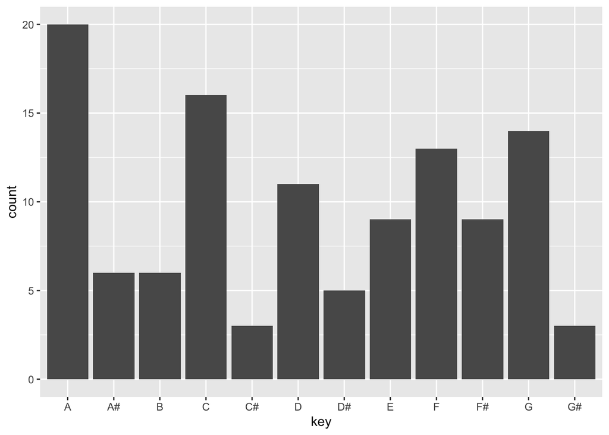

```r
ggplot(data = fleet) +
  aes(x = key) +
  geom_bar()
```

- Question 5 - on which Fleetwood Mac albums are there the biggest number of tracks that are labelled as “explicit”?

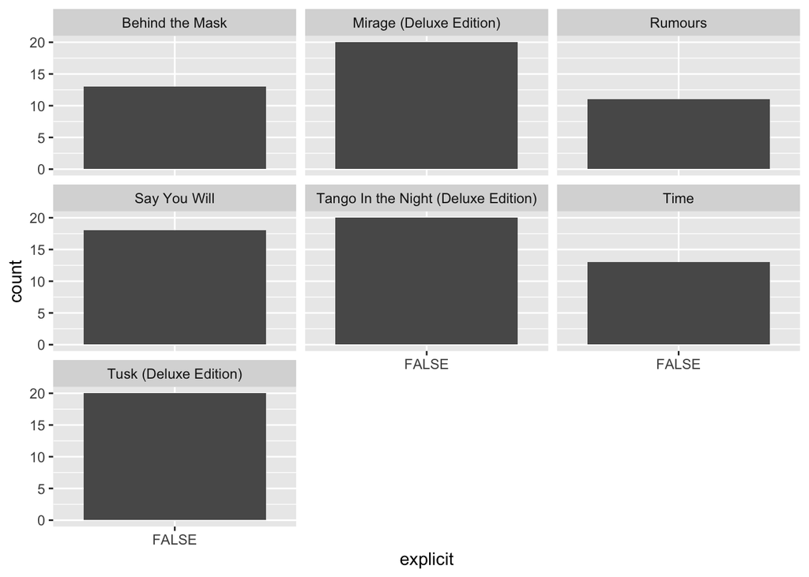

```r
ggplot(data = fleet) +
  aes(x = explicit) +
  geom_bar() +
  facet_wrap(~album)
```

- Question 6 - Which Taylor Swift album has the highest average danceability?

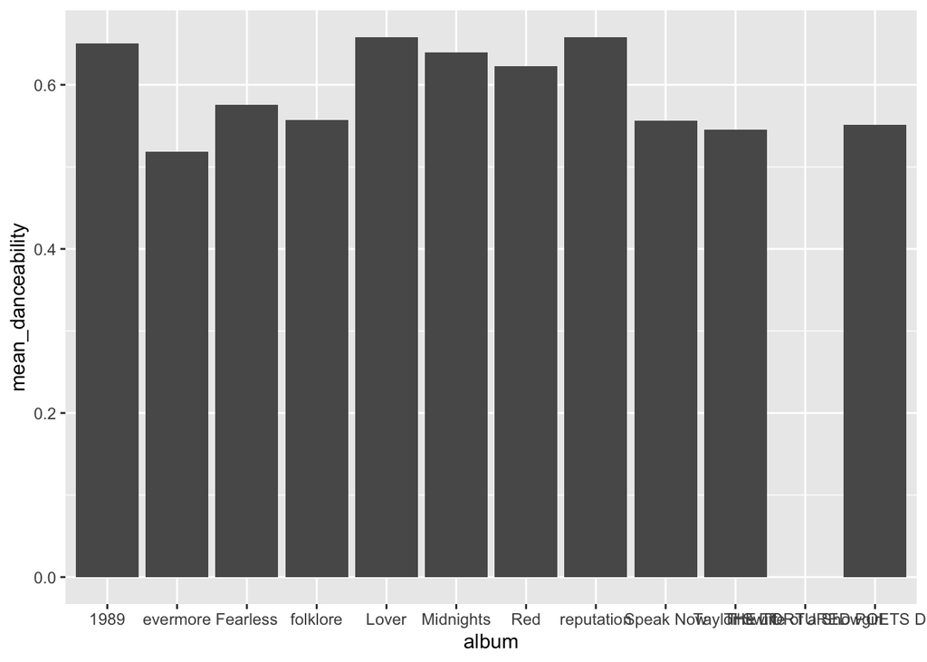

```r
taylor %>%
  group_by(album) %>%
  summarise(mean_danceability = mean(danceability)) %>%
  ggplot() +
  aes(x = album, y = mean_danceability) +
  geom_col()
```

- Final question: show me something interesting!

There was a great mix here!